# Group Project 1

Biology 368/664 Bucknell University

Prof. Ken Field

9 Feb 2022

This project will require you to develop a tutorial to teach Bucknell students how to use R for graphing and data analysis.

## Target Audience

Discuss with your group the target audience for the tutorial. Examples could be one of the new core Biology classes, another 300-level course (not 364), or a research group.

#####Target audiance is any ecology/biology student who has taken field data, the goal is to clean up field data so it is in a useable form for analysis.

```r
summer21_data <- read.csv(file = 'summer21UNclean.csv')
```

```
summer21_data <- read.csv(file = 'summer21UNclean.csv')
print(summer21_data)
```

```
summer21_data <- read.csv(file = 'summer21UNclean.csv')
print(summer21_data)
```

| Stoney.Run | Date | Label | Time | Absorbance | Phosphorus | X | X.1 | X.2 | Conley.Run | Date.1 | Label.1 | Time.1 | Absorbance.1 | Phosphorus.1 | X.3 | X.4 | X.5 | Stoney.Run.1 | Date.2 | Label.2 | Time.2 | Absorbance.2 | Phosphorus.2 | X.6 | X.7 | X.8 | Conley.Run.1 | Date.3 | Label.3 | … |
| --- | --- | --- | --- | --- | --- | --- | --- | --- | --- | --- | --- | --- | --- | --- | --- | --- | --- | --- | --- | --- | --- | --- | --- | --- | --- | --- | --- | --- | --- | --- |
| Stoney Run | 6/14/21 | High1 | 5 | 0.597 | 92.72561 | NA | NA | NA | Conley Run | 6/15/21 | High 1 | 5 | 0.614 | 96.31538 | NA | NA | NA | Stoney Run | 6/30/21 | High1 | 5 | 0.785 | 125.21450 | NA | NA | NA | Conley Run | 6/29/21 | High1 | … |
| Stoney Run | 6/14/21 | High 1 | 10 | 0.567 | 88.07149 | NA | NA | NA | Conley Run | 6/15/21 | High 1 | 10 | 0.603 | 94.59797 | NA | NA | NA | Stoney Run | 6/30/21 | High 1 | 10 | 0.703 | 111.93690 | NA | NA | NA | Conley Run | 6/29/21 | High 1 | … |
| Stoney Run | 6/14/21 | High 1 | 20 | 0.527 | 81.86599 | NA | NA | NA | Conley Run | 6/15/21 | High 1 | 20 | 0.536 | 84.13739 | NA | NA | NA | Stoney Run | 6/30/21 | High 1 | 20 | 0.658 | 104.65040 | NA | NA | NA | Conley Run | 6/29/21 | High 1 | … |
| Stoney Run | 6/14/21 | High 1 | 40 | 0.450 | 69.92041 | NA | NA | NA | Conley Run | 6/15/21 | High 1 | 40 | 0.462 | 72.58392 | NA | NA | NA | Stoney Run | 6/30/21 | High 1 | 40 | 0.538 | 85.21973 | NA | NA | NA | Conley Run | 6/29/21 | High 1 | … |
| Stoney Run | 6/14/21 | High 1 | 60 | 0.374 | 58.84465 | NA | NA | NA | Conley Run | 6/15/21 | High 1 | 60 | 0.400 | 62.90398 | NA | NA | NA | Stoney Run | 6/30/21 | High 1 | 60 | 0.467 | 73.72324 | NA | NA | NA | Conley Run | 6/29/21 | High 1 | … |
| Stoney Run | 6/14/21 | High 2 | 5 | 0.558 | 86.67525 | NA | NA | NA | Conley Run | 6/15/21 | High 2 | 5 | 0.633 | 99.28181 | NA | NA | NA | Stoney Run | 6/30/21 | High 2 | 5 | 0.667 | 106.10770 | NA | NA | NA | Conley Run | 6/29/21 | High 2 | … |
| Stoney Run | 6/14/21 | High 2 | 10 | 0.515 | 80.00434 | NA | NA | NA | Conley Run | 6/15/21 | High 2 | 10 | 0.734 | 115.05070 | NA | NA | NA | Stoney Run | 6/30/21 | High 2 | 10 | 0.705 | 112.26080 | NA | NA | NA | Conley Run | 6/29/21 | High 2 | … |
| Stoney Run | 6/14/21 | High 2 | 20 | 0.473 | 73.48857 | NA | NA | NA | Conley Run | 6/15/21 | High 2 | 20 | 0.690 | 108.18110 | NA | NA | NA | Stoney Run | 6/30/21 | High 2 | 20 | 0.658 | 104.65040 | NA | NA | NA | Conley Run | 6/29/21 | High 2 | … |
| Stoney Run | 6/14/21 | High 2 | 40 | 0.320 | 50.41374 | NA | NA | NA | Conley Run | 6/15/21 | High 2 | 40 | 0.618 | 96.93989 | NA | NA | NA | Stoney Run | 6/30/21 | High 2 | 40 | 0.544 | 86.19126 | NA | NA | NA | Conley Run | 6/29/21 | High 2 | … |
| Stoney Run | 6/14/21 | High 2 | 60 | 0.269 | 42.45121 | NA | NA | NA | Conley Run | 6/15/21 | High 2 | 60 | 0.419 | 65.87041 | NA | NA | NA | Stoney Run | 6/30/21 | High 2 | 60 | 0.440 | 69.35134 | NA | NA | NA | Conley Run | 6/29/21 | High 2 | … |

[output cut: 50 more lines]

```
# print number of columns
print (ncol(summer21_data))
```

```
[1] 33
```

```r
# print number of rows
print(nrow(summer21_data))
```

```
[1] 60
```

####upon looking at the data, it is clear there are unnecessary spaces between datasets, column headers, and the data is wide instead of long. We will first start by removing the spaces between datasets and column headers. gsub is a great way to remove unwanted spaces in strings of data.

```r
newsummer21<-gsub(" ", " ", summer21_data)
```

```r
summer21cleaned <- summer21_data[ -c(7:9,16:18,25:27) ]
```

#### this worked to remove the extra spacing between the data sets. Now we will focus on changing our data from wide data to long data.

```r
gather(summer21cleaned)
```

[output not shown]

###The code below is used to explaim how to create a graph with two variables. Here we are using ggplot to show how Absorbance and Phosphorus levels interact.

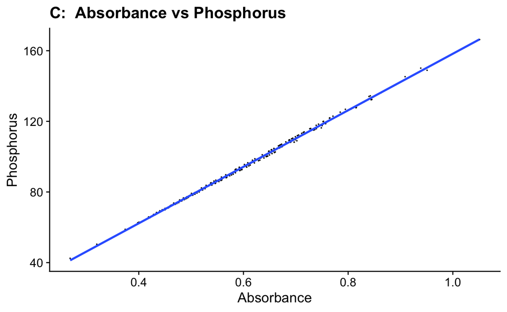

```r
 ggplot(summer21clean, aes(x = Absorbance, y = Phosphorus)) +
  geom_point(position = "jitter",size=0.05) +
  geom_smooth(method='lm',se=FALSE) +
  ggtitle('C:  Absorbance vs Phosphorus') +
  theme_cowplot()
```

###It is seen in the graph above that there is a linear trend between absorbance and phosphorus levels.

## Groups

You will work with the same groups as for the Homework 2 Peer review.

```r
PeerGroups1 <- read_csv("../00-Syllabus/PeerGroups1.csv")
PeerGroups1 %>%
  select(-MAJR, -CLAS, ) %>%
  print()
```

```r
PeerGroups1 <- read_csv("../00-Syllabus/PeerGroups1.csv")
```

```
Error: '../00-Syllabus/PeerGroups1.csv' does not exist in current working directory ('/Users/sierrarider/Desktop/My Working Directory/Tutorial_Project_1').
```

```r
PeerGroups1 <- read_csv("../00-Syllabus/PeerGroups1.csv")
```

```
Error: '../00-Syllabus/PeerGroups1.csv' does not exist in current working directory ('/Users/sierrarider/Desktop/My Working Directory/Tutorial_Project_1').
```

## Grading

Each student will be expected to complete the following tasks to earn 85% of the points available for this assignment (21/25).

- Identify and obtain suitable dataset
- Use a Github repository and version control to collaborate on the project
- Spend 4-6 hours preparing, coding, and testing tutorial
  - Data exploration
  - Data visualization
  - Hypothesis testing
- Present tutorial in class
- Provide public archive suitable for sharing to students/faculty

Tutorials from previous classes can be viewed at our public github site: https://github.com/Bucknell-Biol364

Each group should use an *Acknowledgements* section to document the participation of each member and the collaboration within and between groups.

Additional credit will be awarded for providing assistance to other groups and for the development of a tutorial that goes beyond the minimal expectations listed above.

## Sample Dataset

One of the possible datasets to use for the tutorial can be found in the datasauRus package.

```r
datasaurus_dozen %>%
  group_by(dataset) %>%
  summarize(
      mean_x    = mean(x),
      mean_y    = mean(y),
      std_dev_x = sd(x),
      std_dev_y = sd(y),
      corr_x_y  = cor(x, y)
      )
```

[output not shown]

```r
ggplot(datasaurus_dozen, aes(x = x, colour = dataset))+
    geom_boxplot()+
    theme_void()+
    theme(legend.position = "none")+
    facet_wrap(~dataset, ncol = 3)
```

```
Error in ggplot(datasaurus_dozen, aes(x = x, colour = dataset)) :
  could not find function "ggplot"
```

```r
ggplot(datasaurus_dozen, aes(x = y, colour = dataset))+
    geom_boxplot()+
    theme_void()+
    theme(legend.position = "none")+
    facet_wrap(~dataset, ncol = 3)
```

[output not shown]

But you have to visualize all of the data with a scatter plot to really see the patterns.

```r
  ggplot(datasaurus_dozen, aes(x = x, y = y, colour = dataset))+
    geom_point()+
    theme_void()+
    theme(legend.position = "none")+
    facet_wrap(~dataset, ncol = 3)
```

[output not shown]

And did you notice the code in the {r} codechunk header that controlled the size of the output in the Rmd? Pretty neat trick!

And here are two versions of the data that you could use in your data visualization tutorial. To use them you would probably want to change the names of the datasets and also make x and y more meaningful. Then save them as a csv or tsv to be imported later for your tutorial.

```r
datasaurus_long <- datasaurus_dozen
datasaurus_wide <- datasaurus_dozen_wide
head(datasaurus_long)
head(datasaurus_wide)
```

# Acknowledgements

DatasauRus package and description below: Stephanie Locke https://github.com/jumpingrivers/datasauRus

The datasauRus package wraps the awesome Datasaurus Dozen dataset, which contains 13 sets of x-y data. Each sub-dataset has five statistics that are (almost) the same in each case. (These are the mean of x, mean of y, standard deviation of x, standard deviation of y, and Pearson correlation between x and y). However, scatter plots reveal that each sub-dataset looks very different. The dataset is intended to be used to teach students that it is important to plot their own datasets, rather than relying only on statistics.

The Datasaurus was created by Alberto Cairo in this great [blog post](http://www.thefunctionalart.com/2016/08/download-datasaurus-never-trust-summary.html).

He’s been subsequently made even more famous in the paper [Same Stats, Different Graphs: Generating Datasets with Varied Appearance and Identical Statistics through Simulated Annealing](https://www.autodeskresearch.com/publications/samestats) by Justin Matejka and George Fitzmaurice.

In the paper, Justin and George simulate a variety of datasets that the same summary statistics to the Datasaurus but have very different distributions.

This package also makes these datasets available for use as an advanced [Anscombe’s Quartet](https://en.wikipedia.org/wiki/Anscombe%27s_quartet), available in R as `anscombe`.